# Viabilidad 19

A y B (5 años) con conflicto VAN/TIR (Fisher 10.7%), C de 4 años; k = 6%

# Enunciado

Una empresa debe elegir **una sola** de tres inversiones excluyentes (flujos de caja en k€ al final de cada año; el año 0 es la inversión). A y B duran 5 años; C dura 4 y puede repetirse indefinidamente en las mismas condiciones. La tasa de descuento es del 6%.

1. Calcule el VAN, la TIR y el payback de A y de B. ¿Qué proyecto prefiere cada criterio?

2. Explique por qué VAN y TIR pueden discrepar entre proyectos excluyentes. Calcule la tasa de Fisher (la que iguala los VAN) a partir de los flujos diferenciales A − B y dibuje los dos perfiles de VAN.

3. ¿Para qué tasas de descuento se prefiere A y para cuáles B? ¿Cuál es la decisión correcta a la tasa dada y por qué manda el VAN?

4. C tiene menor vida. Compare C con la mejor de A y B mediante la anualidad equivalente (o la cadena de repeticiones). ¿Cambia la decisión?

Tabla 1: Flujos de caja de las alternativas (k€)

| year | A | B | C |
| --- | --- | --- | --- |
| 0 | -650 | -650 | -390 |
| 1 | 120 | 250 | 150 |
| 2 | 145 | 205 | 150 |
| 3 | 185 | 175 | 150 |
| 4 | 230 | 145 | 150 |
| 5 | 290 | 120 | 0 |

# Resolución

## Apartado 1

1. Calcule el VAN, la TIR y el payback de A y de B. ¿Qué proyecto prefiere cada criterio?

VAN (valor actual neto) a la tasa de descuento, TIR (tasa interna de rentabilidad, la que anula el VAN) y periodo de recuperación (payback) de cada proyecto, con los cálculos:

**A.** VAN = Σ flujo_t/(1 + k)^t = −650.0 + 120.0/1.06¹ + 145.0/1.06² + 185.0/1.06³ + 230.0/1.06⁴ + 290.0/1.06⁵ = −650.0 + 113.2 + 129.0 + 155.3 + 182.2 + 216.7 = **146.5 k€**. La TIR es la tasa que anula el VAN. Probando tasas: VAN(12%) = 15.1 k€ y VAN(13%) = −3.6 k€ tienen signo distinto, así que la TIR está entre 12% y 13%; interpolando linealmente, TIR ≈ 12% + 1 % × 15.1/(15.1 − (−3.6)) = 12.81%. Afinando (bisección, o =TIR(rango de flujos) en la hoja de cálculo): **TIR = 12.81%**. Comprobación: VAN(12.81%) = 0.0000 ≈ 0. Payback: el acumulado pasa de −200.0 (año 3) a 30.0 (año 4); dentro del año 4 se recuperan los 200.0 k€ que faltaban con un flujo de 230.0: payback = 3 + 200.0/230.0 = **3.87 años**; descontado: el acumulado descontado pasa de −70.2 (año 4) a 146.5 (año 5); dentro del año 5 se recuperan los 70.2 k€ que faltaban con un flujo descontado de 216.7: payback = 4 + 70.2/216.7 = **4.32 años**.

**B.** VAN = Σ flujo_t/(1 + k)^t = −650.0 + 250.0/1.06¹ + 205.0/1.06² + 175.0/1.06³ + 145.0/1.06⁴ + 120.0/1.06⁵ = −650.0 + 235.8 + 182.4 + 146.9 + 114.9 + 89.7 = **119.8 k€**. La TIR es la tasa que anula el VAN. Probando tasas: VAN(13%) = 7.1 k€ y VAN(14%) = −6.7 k€ tienen signo distinto, así que la TIR está entre 13% y 14%; interpolando linealmente, TIR ≈ 13% + 1 % × 7.1/(7.1 − (−6.7)) = 13.52%. Afinando (bisección, o =TIR(rango de flujos) en la hoja de cálculo): **TIR = 13.51%**. Comprobación: VAN(13.51%) = 0.0000 ≈ 0. Payback: el acumulado pasa de −20.0 (año 3) a 125.0 (año 4); dentro del año 4 se recuperan los 20.0 k€ que faltaban con un flujo de 145.0: payback = 3 + 20.0/145.0 = **3.14 años**; descontado: el acumulado descontado pasa de −84.8 (año 3) a 30.1 (año 4); dentro del año 4 se recuperan los 84.8 k€ que faltaban con un flujo descontado de 114.9: payback = 3 + 84.8/114.9 = **3.74 años**.

Tabla 2: Criterios para A y B

|  | VAN (k€) | TIR | payback (años) | payback descontado |
| --- | --- | --- | --- | --- |
| A | 146.5 | 12.81% | 3.87 | 4.32 |
| B | 119.8 | 13.51% | 3.14 | 3.74 |

**Respuesta:** el VAN prefiere A (146.5 frente a 119.8 k€); la TIR prefiere B (13.51% frente a 12.81%); el payback prefiere B (recupera la inversión en 3.14 años frente a 3.87). VAN y TIR discrepan.

## Apartado 2

2. Explique por qué VAN y TIR pueden discrepar entre proyectos excluyentes. Calcule la tasa de Fisher (la que iguala los VAN) a partir de los flujos diferenciales A − B y dibuje los dos perfiles de VAN.

La TIR es una medida *relativa* (rentabilidad por euro y año) y supone la reinversión de los flujos a la propia TIR; el VAN es *absoluto* (euros de valor creado a la tasa de descuento). Cuando los proyectos tienen distinto perfil temporal (A cobra tarde, B cobra pronto) sus perfiles de VAN se cruzan: a la tasa de Fisher ambos valen lo mismo. Como VAN_A − VAN_B es el VAN de los flujos diferenciales A − B, la tasa de Fisher es la TIR de esos flujos.

| año | 0 | 1 | 2 | 3 | 4 | 5 |
| --- | --- | --- | --- | --- | --- | --- |
| A | -650 | 120 | 145 | 185 | 230 | 290 |
| B | -650 | 250 | 205 | 175 | 145 | 120 |
| A − B | 0 | -130 | -60 | 10 | 85 | 170 |

Flujos A − B: Su TIR es la tasa que anula su VAN. Probando tasas: VAN(10%) = 3.4 k€ y VAN(11%) = −1.6 k€ tienen signo distinto, así que la TIR está entre 10% y 11%; interpolando linealmente, TIR ≈ 10% + 1 % × 3.4/(3.4 − (−1.6)) = 10.67%. Afinando (bisección, o =TIR(rango de flujos) en la hoja de cálculo): **TIR = 10.67%**. Comprobación: VAN(10.67%) = 0.0000 ≈ 0.

**Respuesta:** tasa de Fisher = 10.67%; a esa tasa VAN_A = 41.4 k€ = VAN_B = 41.4 k€ (los perfiles se cortan en el gráfico).

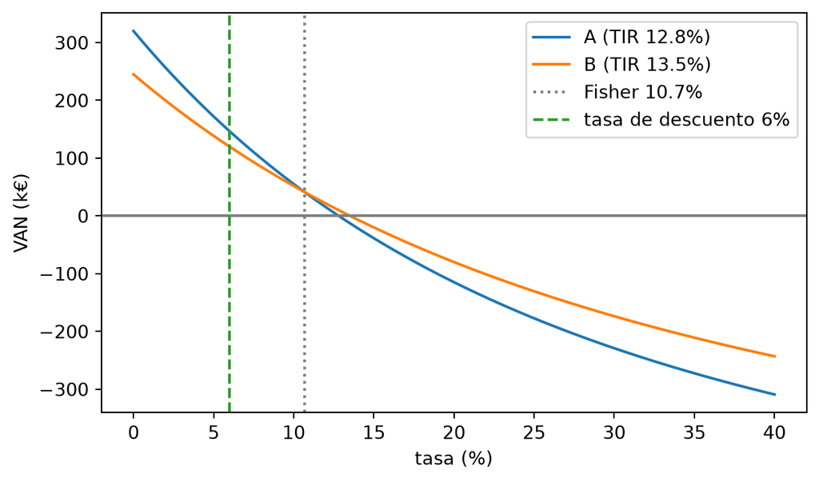

Figura 1: Perfiles de VAN de A y B

## Apartado 3

3. ¿Para qué tasas de descuento se prefiere A y para cuáles B? ¿Cuál es la decisión correcta a la tasa dada y por qué manda el VAN?

**Respuesta:** para tasas por debajo de la de Fisher (10.67%) se prefiere A (sus flujos tardíos valen más cuando el descuento es suave); por encima, B (hasta su TIR, 13.51%; por encima de ambas TIR ninguno es viable). A la tasa dada (6% < 10.67%) la decisión correcta es **A**, la de mayor VAN (146.5 frente a 119.8 k€): el objetivo es maximizar el valor creado en euros, y la TIR, al ser relativa e implicar reinversión a la propia TIR, no compara bien proyectos de distinto perfil temporal.

## Apartado 4

4. C tiene menor vida. Compare C con la mejor de A y B mediante la anualidad equivalente (o la cadena de repeticiones). ¿Cambia la decisión?

|  | VAN (k€) | vida | AE = VAN · k / [1 − (1 + k)^−n] |
| --- | --- | --- | --- |
| A | 146.5 | 5 | 146.5 × 0.06 / [1 − 1.06^−5] = 34.77 |
| B | 119.8 | 5 | 119.8 × 0.06 / [1 − 1.06^−5] = 28.43 |
| C | 129.8 | 4 | 129.8 × 0.06 / [1 − 1.06^−4] = 37.45 |

VAN de C: VAN = Σ flujo_t/(1 + k)^t = −390.0 + 150.0/1.06¹ + 150.0/1.06² + 150.0/1.06³ + 150.0/1.06⁴ = −390.0 + 141.5 + 133.5 + 125.9 + 118.8 = **129.8 k€**. Cadenas de repeticiones hasta 20 años: A, 146.5 + 146.5/1.06⁵ + 146.5/1.06¹⁰ + 146.5/1.06¹⁵ = 398.8 k€; C, 129.8 + 129.8/1.06⁴ + 129.8/1.06⁸ + 129.8/1.06¹² + 129.8/1.06¹⁶ = 429.5 k€. **Respuesta:** C pasa a ser la mejor opción: su anualidad equivalente (37.4 k€/año) supera la de A (34.8), aunque su VAN aislado sea menor.